# Codebook

## Income.mos

| Feature | Result |
| --- | --- |
| Variable type | numeric |
| Number of missing obs. | 0 (0 %) |
| Number of unique values | 274 |
| Median | 2887.5 |
| 1st and 3rd quartiles | 2386; 3902.5 |
| Min. and max. | 1009; 9724 |

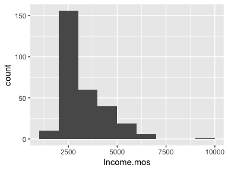

## Rate.mos

| Feature | Result |
| --- | --- |
| Variable type | numeric |
| Number of missing obs. | 0 (0 %) |
| Number of unique values | 291 |
| Median | 13522 |
| 1st and 3rd quartiles | 7637; 19987.25 |
| Min. and max. | 2122; 26999 |

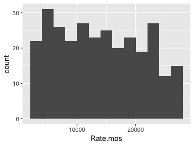

## Jobs.Worked

| Feature | Result |
| --- | --- |
| Variable type | numeric |
| Number of missing obs. | 0 (0 %) |
| Number of unique values | 10 |
| Median | 1 |
| 1st and 3rd quartiles | 1; 4 |
| Min. and max. | 0; 9 |

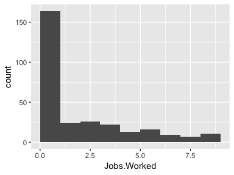

## Over18

- The variable only takes one (non-missing) value: "Y". The variable contains 0 % missing observations.

## OT

| Feature | Result |
| --- | --- |
| Variable type | character |
| Number of missing obs. | 0 (0 %) |
| Number of unique values | 2 |
| Mode | “No” |

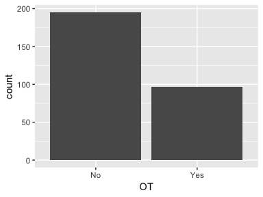

- Observed factor levels: "No", "Yes".

## Percent.Inc

| Feature | Result |
| --- | --- |
| Variable type | numeric |
| Number of missing obs. | 0 (0 %) |
| Number of unique values | 15 |
| Median | 14 |
| 1st and 3rd quartiles | 13; 18 |
| Min. and max. | 11; 25 |

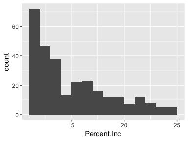

## Performance

| Feature | Result |
| --- | --- |
| Variable type | numeric |
| Number of missing obs. | 0 (0 %) |
| Number of unique values | 2 |
| Median | 3 |
| 1st and 3rd quartiles | 3; 3 |
| Min. and max. | 3; 4 |

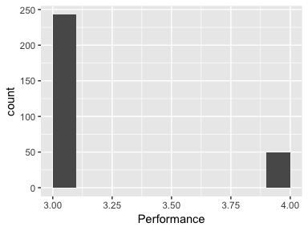

## Sat.Relation

| Feature | Result |
| --- | --- |
| Variable type | numeric |
| Number of missing obs. | 0 (0 %) |
| Number of unique values | 4 |
| Median | 3 |
| 1st and 3rd quartiles | 2; 4 |
| Min. and max. | 1; 4 |

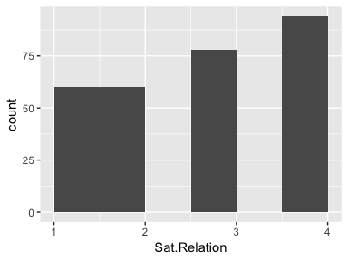

## Hours

- The variable only takes one (non-missing) value: "80". The variable contains 0 % missing observations.

## Stock

| Feature | Result |
| --- | --- |
| Variable type | numeric |
| Number of missing obs. | 0 (0 %) |
| Number of unique values | 4 |
| Median | 1 |
| 1st and 3rd quartiles | 0; 1 |
| Min. and max. | 0; 3 |

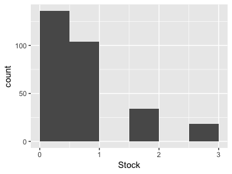

## Yrs.Wrkd

| Feature | Result |
| --- | --- |
| Variable type | numeric |
| Number of missing obs. | 0 (0 %) |
| Number of unique values | 22 |
| Median | 7 |
| 1st and 3rd quartiles | 5; 10 |
| Min. and max. | 0; 25 |

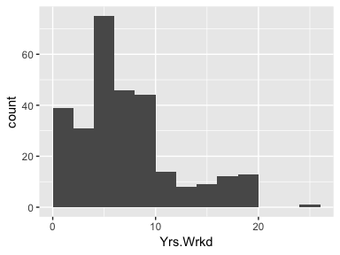

## Training

| Feature | Result |
| --- | --- |
| Variable type | numeric |
| Number of missing obs. | 0 (0 %) |
| Number of unique values | 7 |
| Median | 3 |
| 1st and 3rd quartiles | 2; 3 |
| Min. and max. | 0; 6 |

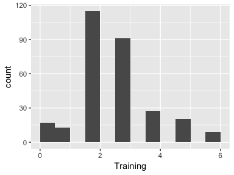

## Work.Life

| Feature | Result |
| --- | --- |
| Variable type | numeric |
| Number of missing obs. | 0 (0 %) |
| Number of unique values | 4 |
| Median | 3 |
| 1st and 3rd quartiles | 2; 3 |
| Min. and max. | 1; 4 |

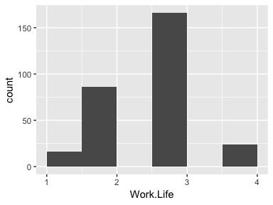

## YOS

| Feature | Result |
| --- | --- |
| Variable type | numeric |
| Number of missing obs. | 0 (0 %) |
| Number of unique values | 19 |
| Median | 4.5 |
| 1st and 3rd quartiles | 2; 7 |
| Min. and max. | 0; 20 |

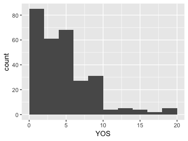

## YCRole

| Feature | Result |
| --- | --- |
| Variable type | numeric |
| Number of missing obs. | 0 (0 %) |
| Number of unique values | 15 |
| Median | 2 |
| 1st and 3rd quartiles | 2; 4 |
| Min. and max. | 0; 15 |

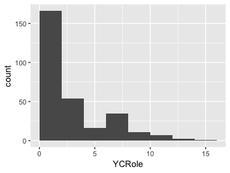

## YbtwnPromo

| Feature | Result |
| --- | --- |
| Variable type | numeric |
| Number of missing obs. | 0 (0 %) |
| Number of unique values | 13 |
| Median | 1 |
| 1st and 3rd quartiles | 0; 2 |
| Min. and max. | 0; 13 |

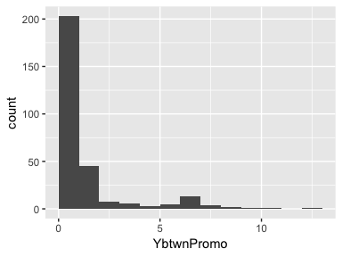

## YwMgmt

| Feature | Result |
| --- | --- |
| Variable type | numeric |
| Number of missing obs. | 0 (0 %) |
| Number of unique values | 14 |
| Median | 2 |
| 1st and 3rd quartiles | 1; 5 |
| Min. and max. | 0; 17 |

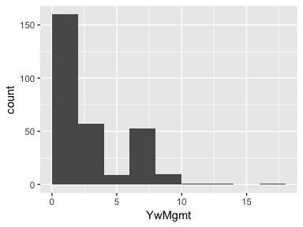

Report generation information:

- dataMaid v1.2.0 [Pkg: 2018-10-03 from CRAN (R 3.5.0)]
- R version 3.5.1 (2018-07-02).
- Platform: x86_64-apple-darwin15.6.0 (64-bit)(macOS Sierra 10.12.6).
- Function call: `makeDataReport(data = Data, mode = c("summarize", "visualize", "check"), smartNum = FALSE, file = "codebook_Data.Rmd", replace = TRUE, checks = list(character = "showAllFactorLevels", factor = "showAllFactorLevels", labelled = "showAllFactorLevels", haven_labelled = "showAllFactorLevels", numeric = NULL, integer = NULL, logical = NULL, Date = NULL), listChecks = FALSE, maxProbVals = Inf, codebook = TRUE, reportTitle = "Codebook for Data")`